# Test of H2: The combination of learner history and fact history is more predictive of the observed rate of forgetting than either of these elements on its own

Maarten van der Velde

Last updated: 2020-04-02 14:58:37

# Overview

This notebook contains the analysis of Hypothesis 2, as preregistered at https://osf.io/vwg6u/:

> The prediction accuracy, expressed as the root mean square error (RMSE) of the predicted rates of forgetting relative to the observed rates of forgetting for each learner/fact combination, is expected to be highest (i.e., the RMSE will be lowest) when the predicted values are based on both the learner's previously measured rates of forgetting on other facts and the rates of forgetting of other learners for this fact. The prediction accuracy is expected to be lower when the prediction is based on only one of these two sources of information. There is no hypothesis as to which of these two sources of information is more predictive on its own.

# Setup

## Load packages

```r
library(BayesFactor)
library(dplyr)
library(forcats)
library(ggplot2)
library(purrr)
library(readr)
library(stringr)
library(tidyr)
library(extrafont)
library(wesanderson)
library(tikzDevice)
library(fst)
# font_import() # Run once to populate the R font database with the fonts on the system
loadfonts(quiet = TRUE)
theme_poster <- theme_light(base_size = 14) +
            theme(text = element_text(family = 'Merriweather Sans'),
                  strip.text = element_text(colour = "black"))
theme_paper <- theme_bw() +
  theme(axis.text = element_text(colour = "black"))
condition_colours <- wes_palette("Darjeeling1", n = 5)
condition_colours[c(2, 4, 5)] <- condition_colours[c(4, 5, 2)]
knitr::opts_chunk$set(fig.width=16, fig.height=16)
set.seed(0)
```

## Load data

```r
final_alpha_lab_2 <- read.fst(file.path("..", "data", "processed", "lab", "session2", "session2_rl2_final_alpha_lab.fst"))
final_alpha_mturk_2 <- read.fst(file.path("..", "data", "processed", "mturk", "session2", "session2_rl2_final_alpha_mturk.fst"))
fix_condition_labels <- function(x) {
  rowwise(x) %>%
  mutate(condition = str_replace(condition, "-and-", " & ") %>%
           str_replace("student", "learner") %>%
           str_to_title()) %>%
  ungroup() %>%
  mutate(condition = fct_relevel(condition, "Fact & Learner", after = Inf)) # Move F&L level to the end
}
final_alpha_lab_2 <- fix_condition_labels(final_alpha_lab_2)
final_alpha_mturk_2 <- fix_condition_labels(final_alpha_mturk_2)
final_alpha_2 <- bind_rows(mutate(final_alpha_lab_2, dataset = "Lab"),
                         mutate(final_alpha_mturk_2, dataset = "MTurk"))
```

## Subset data

The preregistration specified 22 April 2019 as the cutoff date for data collection. We reached the minimum of 25 participants per condition in the lab sample before this date, but not in the Mechanical Turk sample. For that reason data collection on MTurk continued until there were at least 25 participants per condition (14 May 2019) and was stopped only then. The analysis reported in the paper is based only on the data from before the cutoff date, but this notebook also reports the same analysis done on the full dataset.

```r
subjects_cutoff <- read_csv(file.path("..", "data", "processed", "subjects_before_cutoff.csv"))
final_alpha_2_full <- final_alpha_2
final_alpha_2_cutoff <- final_alpha_2 %>%
  right_join(subjects_cutoff, by = "subject")
```

# Predictions

The distribution of predictions is plotted below, separated by condition and dataset. The predictions in the "default" and "domain" condition are of course always the same.

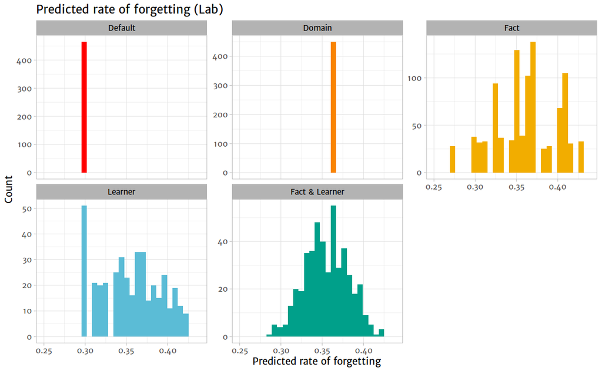

```r
final_alpha_2_cutoff %>%
  filter(dataset == "Lab") %>%
  ggplot(aes(x = prediction, fill = condition)) +
  facet_wrap(~ condition, scales = "free_y") +
  geom_histogram() +
  scale_x_continuous(limits = range(final_alpha_2_cutoff$prediction)) +
  scale_fill_manual(values = condition_colours) +
  guides(fill = FALSE) +
  labs(title = "Predicted rate of forgetting (Lab)",
       x = "Predicted rate of forgetting",
       y = "Count") +
  theme_poster
```

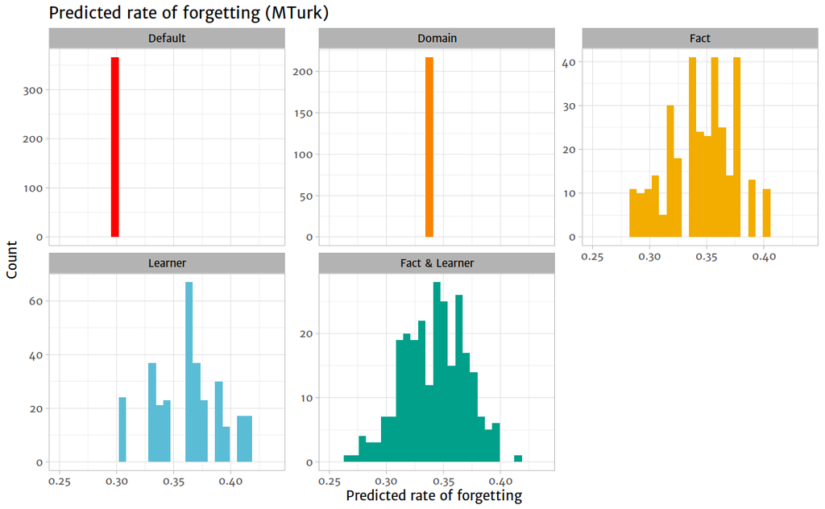

```r
final_alpha_2_cutoff %>%
  filter(dataset == "MTurk") %>%
  ggplot(aes(x = prediction, fill = condition)) +
  facet_wrap(~ condition, scales = "free_y") +
  geom_histogram() +
  scale_x_continuous(limits = range(final_alpha_2_cutoff$prediction)) +
  scale_fill_manual(values = condition_colours) +
  guides(fill = FALSE) +
  labs(title = "Predicted rate of forgetting (MTurk)",
       x = "Predicted rate of forgetting",
       y = "Count") +
  theme_poster
```

# Predicted vs. observed

Compare the predicted rate of forgetting, used as the initial estimate, and the observed rate of forgetting (i.e., the final estimate). Only facts that were repeated at least 3 times are included.

```r
rmse <- function(a, b) {
  sqrt(mean((a - b)^2))
}
pred_acc_by_subj_cutoff <- final_alpha_2_cutoff %>%
  group_by(dataset, condition, subject) %>%
  summarise(correlation = cor(prediction, final_alpha),
            rmse = rmse(prediction, final_alpha)) %>%
  ungroup() %>%
  mutate(dataset = as.factor(dataset),
         condition = as.factor(condition))
```

[output not shown]

```r
pred_acc_by_subj_full <- final_alpha_2_full %>%
  group_by(dataset, condition, subject) %>%
  summarise(correlation = cor(prediction, final_alpha),
            rmse = rmse(prediction, final_alpha)) %>%
  ungroup() %>%
  mutate(dataset = as.factor(dataset),
         condition = as.factor(condition))
```

[output not shown]

```r
pred_acc_by_cond_cutoff <- pred_acc_by_subj_cutoff %>%
  group_by(dataset, condition) %>%
  summarise(correlation_mean = mean(correlation, na.rm = T),
            correlation_sd = sd(correlation, na.rm = T),
            rmse_mean = mean(rmse, na.rm = T),
            rmse_sd = sd(rmse, na.rm = T))
pred_acc_by_cond_full <- pred_acc_by_subj_full %>%
  group_by(dataset, condition) %>%
  summarise(correlation_mean = mean(correlation, na.rm = T),
            correlation_sd = sd(correlation, na.rm = T),
            rmse_mean = mean(rmse, na.rm = T),
            rmse_sd = sd(rmse, na.rm = T))
```

## Cutoff dataset

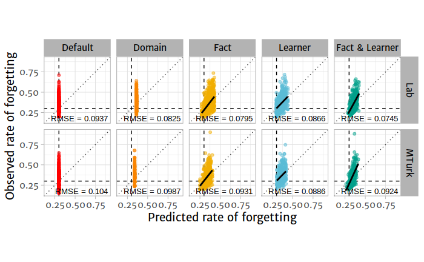

```r
final_alpha_2_cutoff %>%
  ggplot(aes(x = prediction, y = final_alpha, colour = condition)) +
  facet_grid(dataset ~ condition) +
  geom_hline(yintercept = 0.3, lty = 2) +
  geom_vline(xintercept = 0.3, lty = 2) +
  geom_abline(slope = 1, intercept = 0, lty = 3, alpha = 0.75) +
  geom_point(alpha = 0.5) +
  geom_smooth(method = "lm", colour = "black") +
  geom_text(aes(label = paste("RMSE =", formatC(rmse_mean, digits = 3, flag = "#"))), x = max(final_alpha_2_cutoff$final_alpha), y = min(final_alpha_lab_2$final_alpha), hjust = 1, colour = "black", size = 3.5, data = pred_acc_by_cond_cutoff) +
  coord_fixed(ratio = 1) +
  scale_x_continuous(limits = range(final_alpha_2_cutoff$final_alpha)) +
  scale_y_continuous(limits = range(final_alpha_2_cutoff$final_alpha)) +
  scale_colour_manual(values = condition_colours) +
  guides(colour = FALSE) +
  labs(x = "Predicted rate of forgetting",
       y = "Observed rate of forgetting") +
  theme_poster
ggsave("../output/prediction_rmse_cutoff.pdf", device = "pdf", width = 10, height = 6)
```

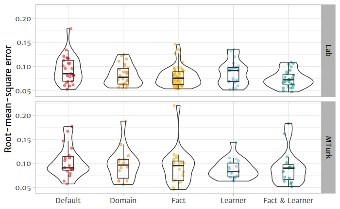

```r
ggplot(pred_acc_by_subj_cutoff, aes(x = condition, y = rmse)) +
  facet_grid(dataset ~ .) +
  geom_jitter(width = 0.1, height = 0, alpha = 0.5, aes(colour = condition)) +
  geom_violin(fill = NA) +
  geom_boxplot(width = 0.2, outlier.shape = NA, fill = NA) +
  guides(colour = FALSE) +
  scale_colour_manual(values = condition_colours) +
  labs(x = NULL,
       y = "Root-mean-square error") +
  theme_poster
```

Prediction accuracy looks to be higher in the conditions involving prediction than in the default condition, which is as expected. The combined fact-and-student distribution seems to create the most accurate predictions in the lab data; the learner prediction seems to be most accurate in the MTurk data.

We test the effect of condition on the prediction accuracy (RMSE) with a Bayesian ANOVA, which includes an interaction with population to test H5 (no effect of population):

```r
bf_pred_acc <- anovaBF(
  rmse ~ condition * dataset,
  data = pred_acc_by_subj_cutoff,
  progress = FALSE
)
```

```
data coerced from tibble to data frame
```

Evidence for this model over a null model (no effect of condition or dataset):

```r
bf_pred_acc
```

```
Bayes factor analysis
--------------
[1] dataset                                 : 53.22705  ±0%
[2] condition                               : 0.9577542 ±0%
[3] dataset + condition                     : 27.52106  ±1.62%
[4] dataset + condition + dataset:condition : 2.019127  ±1.3%

Against denominator:
  Intercept only
---
Bayes factor type: BFlinearModel, JZS
```

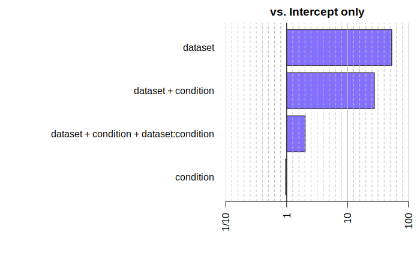

```r
plot(bf_pred_acc)
```

There is evidence for an overall effect of dataset, so we repeat the analysis separately for each population.

In the lab data there is only weak evidence for an effect of condition on the prediction accuracy (RMSE), so this will not be followed up further:

```r
bf_pred_acc_lab <- anovaBF(
  rmse ~ condition,
  data = filter(pred_acc_by_subj_cutoff, dataset == "Lab"),
  progress = FALSE
)
```

```
data coerced from tibble to data frame
```

```r
bf_pred_acc_lab
```

```
Bayes factor analysis
--------------
[1] condition : 1.323776 ±0%

Against denominator:
  Intercept only
---
Bayes factor type: BFlinearModel, JZS
```

In the MTurk data there is evidence against an effect of condition on the prediction accuracy (RMSE), so this will also not be followed up further:

```r
bf_pred_acc_mturk <- anovaBF(
  rmse ~ condition,
  data = filter(pred_acc_by_subj_cutoff, dataset == "MTurk"),
  progress = FALSE
)
```

```
data coerced from tibble to data frame
```

```r
bf_pred_acc_mturk
```

```
Bayes factor analysis
--------------
[1] condition : 0.1006113 ±0%

Against denominator:
  Intercept only
---
Bayes factor type: BFlinearModel, JZS
```

```r
1/bf_pred_acc_mturk
```

```
Bayes factor analysis
--------------
[1] Intercept only : 9.939238 ±0%

Against denominator:
  rmse ~ condition
---
Bayes factor type: BFlinearModel, JZS
```

**Conclusion: weak/no effect of condition on prediction accuracy (RMSE), but overall difference between populations.**

## Full dataset

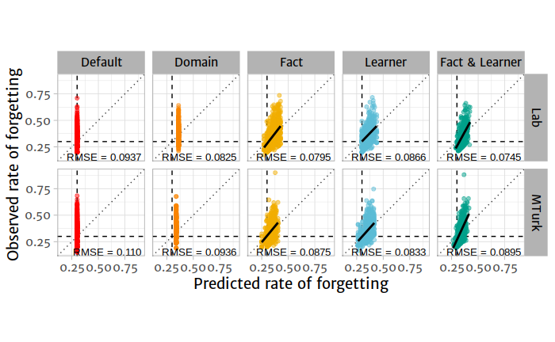

```r
final_alpha_2_full %>%
  ggplot(aes(x = prediction, y = final_alpha, colour = condition)) +
  facet_grid(dataset ~ condition) +
  geom_hline(yintercept = 0.3, lty = 2) +
  geom_vline(xintercept = 0.3, lty = 2) +
  geom_abline(slope = 1, intercept = 0, lty = 3, alpha = 0.75) +
  geom_point(alpha = 0.5) +
  geom_smooth(method = "lm", colour = "black") +
  geom_text(aes(label = paste("RMSE =", formatC(rmse_mean, digits = 3, flag = "#"))), x = max(final_alpha_2_full$final_alpha), y = min(final_alpha_2_full$final_alpha), hjust = 1, colour = "black", size = 3.5, data = pred_acc_by_cond_full) +
  coord_fixed(ratio = 1) +
  scale_x_continuous(limits = range(final_alpha_2_full$final_alpha)) +
  scale_y_continuous(limits = range(final_alpha_2_full$final_alpha)) +
  scale_colour_manual(values = condition_colours) +
  guides(colour = FALSE) +
  labs(x = "Predicted rate of forgetting",
       y = "Observed rate of forgetting") +
  theme_poster
ggsave("../output/prediction_rmse_full.pdf", device = "pdf", width = 10, height = 6)
```

Make the plot shown in the paper:

```r
final_alpha_2_full_tex <- final_alpha_2_full
levels(final_alpha_2_full_tex$condition)[5] <- "Fact \\& Learner"
pred_acc_by_cond_full_tex <- pred_acc_by_cond_full
levels(pred_acc_by_cond_full_tex$condition)[5] <- "Fact \\& Learner"
p <- final_alpha_2_full_tex %>%
  ggplot(aes(x = prediction, y = final_alpha, colour = condition)) +
  facet_grid(dataset ~ condition) +
  geom_hline(yintercept = 0.3, lty = 2) +
  geom_vline(xintercept = 0.3, lty = 2) +
  geom_abline(slope = 1, intercept = 0, lty = 3, alpha = 0.75) +
  geom_point(alpha = 0.5) +
  geom_smooth(method = "lm", colour = "black") +
  geom_text(aes(label = paste("RMSE =", formatC(rmse_mean, digits = 3, flag = "#"))), x = max(final_alpha_2_full_tex$final_alpha), y = min(final_alpha_2_full_tex$final_alpha), hjust = 1, colour = "black", size = rel(2), data = pred_acc_by_cond_full_tex) +
  coord_fixed(ratio = 1) +
  scale_x_continuous(limits = range(final_alpha_2_full_tex$final_alpha)) +
  scale_y_continuous(limits = range(final_alpha_2_full_tex$final_alpha)) +
  scale_colour_manual(values = condition_colours) +
  guides(colour = FALSE) +
  labs(x = "Predicted rate of forgetting",
       y = "Observed rate of forgetting") +
  theme_paper
tikz(file = "../output/prediction_rmse_full.tex", width = 6.5, height = 3.5)
p
dev.off()
```

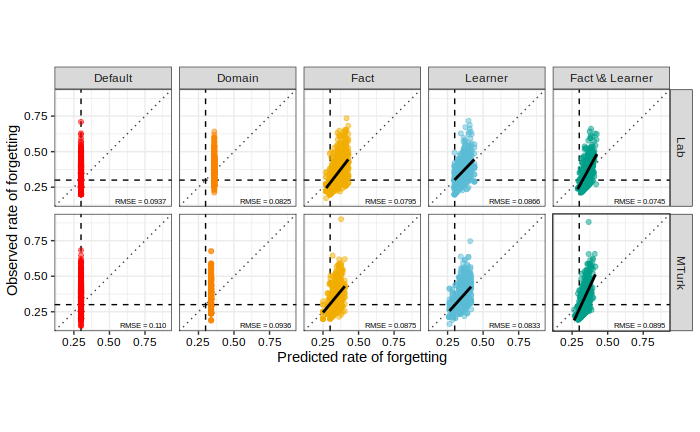

```r
p
```

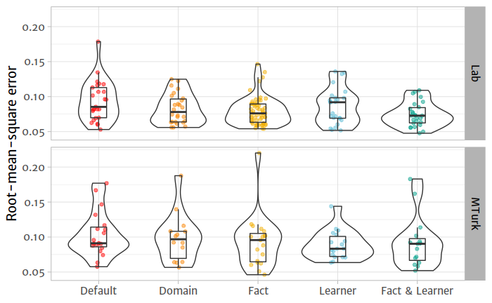

```r
ggplot(pred_acc_by_subj_cutoff, aes(x = condition, y = rmse)) +
  facet_grid(dataset ~ .) +
  geom_jitter(width = 0.1, height = 0, alpha = 0.5, aes(colour = condition)) +
  geom_violin(fill = NA) +
  geom_boxplot(width = 0.2, outlier.shape = NA, fill = NA) +
  guides(colour = FALSE) +
  scale_colour_manual(values = condition_colours) +
  labs(x = NULL,
       y = "Root-mean-square error") +
  theme_poster
```

Repeating the test on the full dataset:

```r
bf_pred_acc_full <- anovaBF(
  rmse ~ condition * dataset,
  data = pred_acc_by_subj_full,
  progress = FALSE
)
```

```
data coerced from tibble to data frame
```

Evidence for this model over a null model (no effect of condition or dataset):

```r
bf_pred_acc_full
```

```
Bayes factor analysis
--------------
[1] dataset                                 : 14.04596 ±0%
[2] condition                               : 43.67988 ±0.01%
[3] dataset + condition                     : 316.0877 ±1.45%
[4] dataset + condition + dataset:condition : 36.19297 ±2.99%

Against denominator:
  Intercept only
---
Bayes factor type: BFlinearModel, JZS
```

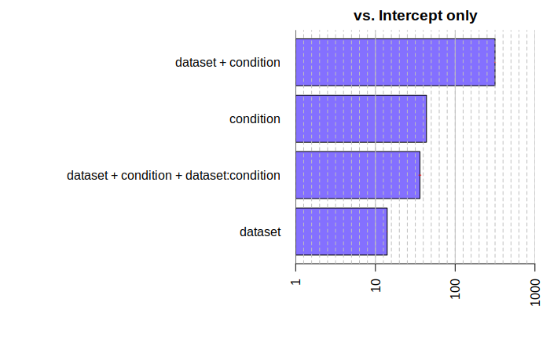

```r
plot(bf_pred_acc_full)
```

```r
max(bf_pred_acc_full)/bf_pred_acc_full
```

```
                     denominator
numerator              dataset condition dataset + condition dataset + condition + dataset:condition
  dataset + condition 22.50381  7.236459                   1                                8.733399
```

There is once again evidence for an overall effect of dataset, so we repeat the analysis separately for each population.

In the lab data there is still only weak evidence for an effect of condition on the prediction accuracy (RMSE), so this will not be followed up further:

```r
bf_pred_acc_lab_full <- anovaBF(
  rmse ~ condition,
  data = filter(pred_acc_by_subj_full, dataset == "Lab"),
  progress = FALSE
)
```

```
data coerced from tibble to data frame
```

```r
bf_pred_acc_lab_full
```

```
Bayes factor analysis
--------------
[1] condition : 1.323776 ±0%

Against denominator:
  Intercept only
---
Bayes factor type: BFlinearModel, JZS
```

In the MTurk data there is now also weak evidence in favour of an effect of condition on the prediction accuracy (RMSE):

```r
bf_pred_acc_mturk_full <- anovaBF(
  rmse ~ condition,
  data = filter(pred_acc_by_subj_full, dataset == "MTurk"),
  progress = FALSE
)
```

```
data coerced from tibble to data frame
```

```r
bf_pred_acc_mturk_full
```

```
Bayes factor analysis
--------------
[1] condition : 1.657438 ±0%

Against denominator:
  Intercept only
---
Bayes factor type: BFlinearModel, JZS
```

**Conclusion: weak effect of condition on prediction accuracy (RMSE), and overall difference between populations.**

```r
1/fully_individual_ttest
```

[output not shown]

```
                 denominator
numerator         Alt., r=0.707 -Inf<d<0 Alt., r=0.707 !(-Inf<d<0)
  Null, mu1-mu2=0               4.430703                  7.021306
```

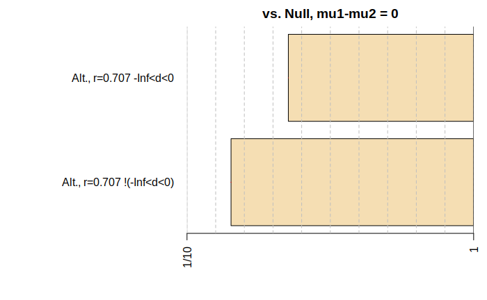

```r
plot(fully_individual_ttest)
```

Separated by population:

```r
ttestBF(filter(pred_acc_by_subj_full, dataset == "Lab", condition == "Fact & Learner")$rmse,
        filter(pred_acc_by_subj_full, dataset == "Lab", condition %in% c("Fact", "Learner"))$rmse,
        nullInterval=c(-Inf, 0))
```

```
Bayes factor analysis
--------------
[1] Alt., r=0.707 -Inf<d<0    : 1.129426  ±0%
[2] Alt., r=0.707 !(-Inf<d<0) : 0.1020823 ±0%

Against denominator:
  Null, mu1-mu2 = 0
---
Bayes factor type: BFindepSample, JZS
```

```r
ttestBF(filter(pred_acc_by_subj_full, dataset == "MTurk", condition == "Fact & Learner")$rmse,
        filter(pred_acc_by_subj_full, dataset == "MTurk", condition %in% c("Fact", "Learner"))$rmse,
        nullInterval=c(-Inf, 0))
```

```
Bayes factor analysis
--------------
[1] Alt., r=0.707 -Inf<d<0    : 0.1697553 ±0%
[2] Alt., r=0.707 !(-Inf<d<0) : 0.4058033 ±0.01%

Against denominator:
  Null, mu1-mu2 = 0
---
Bayes factor type: BFindepSample, JZS
```

## Domain vs. Fact and/or Learner

Combined data:

```r
individual_ttest <- ttestBF(filter(pred_acc_by_subj_full, condition %in% c("Fact & Learner", "Fact", "Learner"))$rmse,
        filter(pred_acc_by_subj_full, condition == "Domain")$rmse,
        nullInterval=c(-Inf, 0))
individual_ttest
```

```
Bayes factor analysis
--------------
[1] Alt., r=0.707 -Inf<d<0    : 0.6836237  ±0%
[2] Alt., r=0.707 !(-Inf<d<0) : 0.07756557 ±0.01%

Against denominator:
  Null, mu1-mu2 = 0
---
Bayes factor type: BFindepSample, JZS
```

```r
1/individual_ttest
```

```
                 denominator
numerator         Alt., r=0.707 -Inf<d<0 Alt., r=0.707 !(-Inf<d<0)
  Null, mu1-mu2=0               1.462793                  12.89232
```

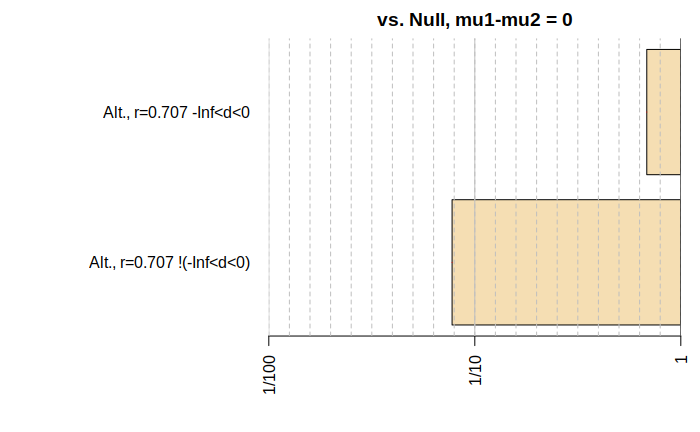

```r
plot(individual_ttest)
```

```r
ttestBF(filter(pred_acc_by_subj_full, dataset == "Lab", condition %in% c("Fact & Learner", "Fact", "Learner"))$rmse,
        filter(pred_acc_by_subj_full, dataset == "Lab", condition == "Domain")$rmse,
        nullInterval=c(-Inf, 0))
```

```
Bayes factor analysis
--------------
[1] Alt., r=0.707 -Inf<d<0    : 0.3612197 ±0%
[2] Alt., r=0.707 !(-Inf<d<0) : 0.1582551 ±0%

Against denominator:
  Null, mu1-mu2 = 0
---
Bayes factor type: BFindepSample, JZS
```

```r
ttestBF(filter(pred_acc_by_subj_full, dataset == "MTurk", condition %in% c("Fact & Learner", "Fact", "Learner"))$rmse,
        filter(pred_acc_by_subj_full, dataset == "MTurk", condition == "Domain")$rmse,
        nullInterval=c(-Inf, 0))
```

```
Bayes factor analysis
--------------
[1] Alt., r=0.707 -Inf<d<0    : 0.6265646 ±0.01%
[2] Alt., r=0.707 !(-Inf<d<0) : 0.1254186 ±0%

Against denominator:
  Null, mu1-mu2 = 0
---
Bayes factor type: BFindepSample, JZS
```

# Exploratory: adaptation vs. no adaptation

As with H1, we are also interested if *any* kind of adaptation actually improves predictions compared to using the default prediction of 0.3.

```r
pred_acc_by_subj_full <- mutate(pred_acc_by_subj_full, adaptation = as.factor(condition != "Default"))
```

```r
bf_pred_acc_full_adaptation <- anovaBF(
  rmse ~ adaptation * dataset,
  data = filter(pred_acc_by_subj_full),
  progress = FALSE
)
```

```
data coerced from tibble to data frame
```

```r
bf_pred_acc_full_adaptation
```

```
Bayes factor analysis
--------------
[1] dataset                                   : 14.04596 ±0%
[2] adaptation                                : 1045.359 ±0%
[3] dataset + adaptation                      : 9021.389 ±2.23%
[4] dataset + adaptation + dataset:adaptation : 3083.073 ±7.01%

Against denominator:
  Intercept only
---
Bayes factor type: BFlinearModel, JZS
```

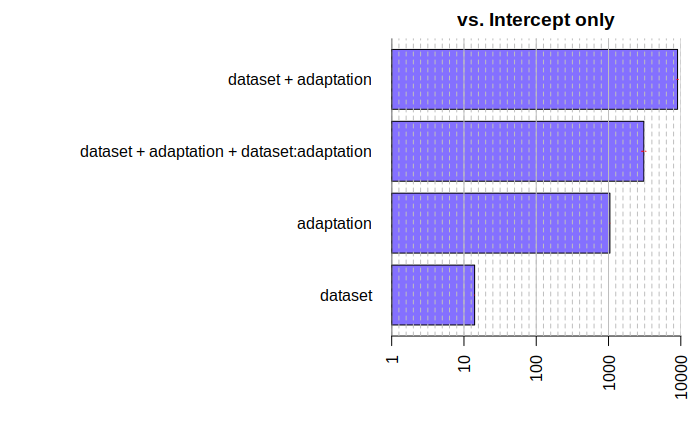

```r
plot(bf_pred_acc_full_adaptation)
```

The effect of adaptation is also present if we split by population.

Lab:

```r
bf_pred_acc_lab_full_adaptation <- anovaBF(
  rmse ~ adaptation,
  data = filter(pred_acc_by_subj_full, dataset == "Lab"),
  progress = FALSE
)
```

```
data coerced from tibble to data frame
```

```r
bf_pred_acc_lab_full_adaptation
```

```
Bayes factor analysis
--------------
[1] adaptation : 5.483047 ±0%

Against denominator:
  Intercept only
---
Bayes factor type: BFlinearModel, JZS
```

MTurk:

```r
bf_pred_acc_mturk_full_adaptation <- anovaBF(
  rmse ~ adaptation,
  data = filter(pred_acc_by_subj_full, dataset == "MTurk"),
  progress = FALSE
)
```

```
data coerced from tibble to data frame
```

```r
bf_pred_acc_mturk_full_adaptation
```

```
Bayes factor analysis
--------------
[1] adaptation : 18.66149 ±0%

Against denominator:
  Intercept only
---
Bayes factor type: BFlinearModel, JZS
```

**Conclusion: there is evidence for an effect of adaptation in general in both datasets.**